# Using neuralnet in R

Jon Landrigan

This is an example script for training a neural network classifier in R. In this example I use the Iris Data Set which is available for download at: https://www.kaggle.com/uciml/iris. In short the dataset contains the data for the sepal length and width as well as the petal length and width for 3 different species of Iris’s (totalling 150 observations).

IMPORTANT: the nerual network may not always converge to the error threshold resulting in the neuralnet function to error out. A good first step in avoiding this issue is increasing the stepmax or increasing the error threshold.

Step1: Read in the required packages and data.

```r
#Read in the required packages
library(neuralnet)
library(caret)
library(reshape2)
library(ggplot2)
library(stringr)

#Read in the data
irisData <- read.csv(file="iris.csv", head = TRUE, sep = ",")
```

Step 2: Take a look at the data to get an idea of what is present in the dataset and what type of data it contains.

```r
#Get a summary of the data
summary(irisData)
```

```
##        Id         SepalLengthCm    SepalWidthCm   PetalLengthCm
##  Min.   :  1.00   Min.   :4.300   Min.   :2.000   Min.   :1.000
##  1st Qu.: 38.25   1st Qu.:5.100   1st Qu.:2.800   1st Qu.:1.600
##  Median : 75.50   Median :5.800   Median :3.000   Median :4.350
##  Mean   : 75.50   Mean   :5.843   Mean   :3.054   Mean   :3.759
##  3rd Qu.:112.75   3rd Qu.:6.400   3rd Qu.:3.300   3rd Qu.:5.100
##  Max.   :150.00   Max.   :7.900   Max.   :4.400   Max.   :6.900
##   PetalWidthCm              Species
##  Min.   :0.100   Iris-setosa    :50
##  1st Qu.:0.300   Iris-versicolor:50
##  Median :1.300   Iris-virginica :50
##  Mean   :1.199
##  3rd Qu.:1.800
##  Max.   :2.500
```

```r
str(irisData)
```

```
## 'data.frame':    150 obs. of  6 variables:
##  $ Id           : int  1 2 3 4 5 6 7 8 9 10 ...
##  $ SepalLengthCm: num  5.1 4.9 4.7 4.6 5 5.4 4.6 5 4.4 4.9 ...
##  $ SepalWidthCm : num  3.5 3 3.2 3.1 3.6 3.9 3.4 3.4 2.9 3.1 ...
##  $ PetalLengthCm: num  1.4 1.4 1.3 1.5 1.4 1.7 1.4 1.5 1.4 1.5 ...
##  $ PetalWidthCm : num  0.2 0.2 0.2 0.2 0.2 0.4 0.3 0.2 0.2 0.1 ...
##  $ Species      : Factor w/ 3 levels "Iris-setosa",..: 1 1 1 1 1 1 1 1 1 1 ...
```

Step 3: Check the data for any missing values. There are multiple ways to do this but in this example I use the colsums function to determine how many missing values are in each column if any.

```r
#Check how many missing values are in each column. Note that this won't always work as sometimes missing data is filled in with dummy values. This code simply gets the totals number of NA values and will be tricked if there are dummy values standing in for true missing data.
colSums(is.na(irisData))
```

```
##            Id SepalLengthCm  SepalWidthCm PetalLengthCm  PetalWidthCm
##             0             0             0             0             0
##       Species
##             0
```

Step 4: Perform any data cleaning tha is necessary. In this ecample I wil remove the “Iris-” from the species column. This is primarly because if left in, it could cause issues later when constructing the model formula but also because it is redundant to have.

```r
irisData$Species <- str_replace(irisData$Species, "Iris-","")
```

Step 5: Look at the data visually to get an idea of which predictors may be the best for the model.

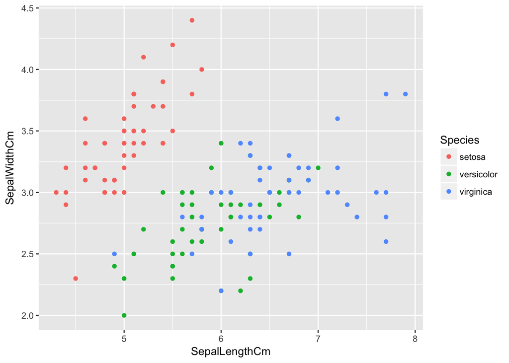

```r
ggplot(irisData, aes(SepalLengthCm, SepalWidthCm, color = Species)) + geom_point()
```

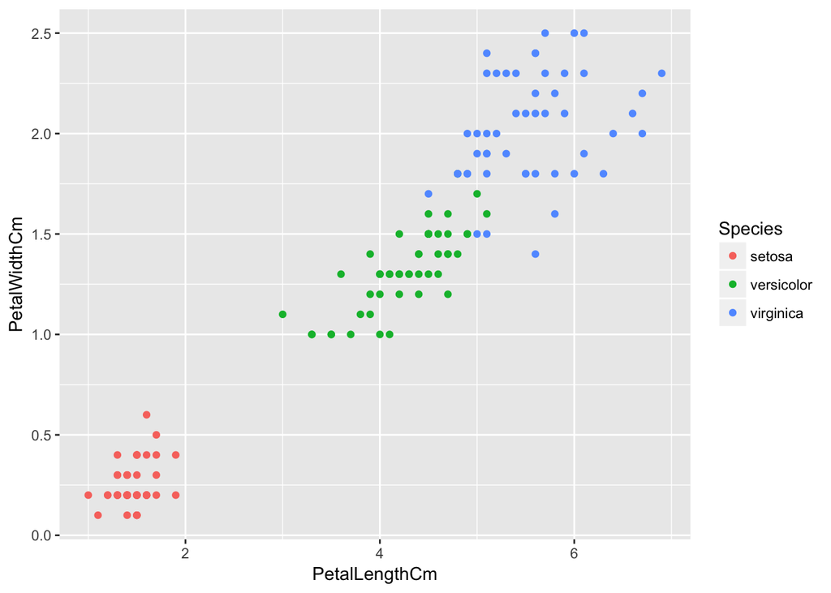

```r
ggplot(irisData, aes(PetalLengthCm, PetalWidthCm, color = Species)) + geom_point()
```

Step 6: In order to feed the data into the network it needs to be normalized or scaled. If it is not scaled the model will either be extremly hard to train or will result in uninterpretable results. Note I am only scaling the feature columns.

```r
irisData[,2:5] <- scale(irisData[,2:5])
```

Step 7: Because the neuralnet package does not like factors, the outcome variable needs to be adjusted. In this example I transform the outcome variable into target vectors across 3 columns.

```r
irisData <- cbind(irisData, model.matrix(~ 0 + Species, irisData))
```

Step 8: Split the data into training and testing data. In this example I split the data so that 75% is used for training and 25% is used for testing.

```r
#set the seed to get reproducible results
set.seed(44)
#Get a random sample of indeces
trainInds <- sample(1:dim(irisData)[1],112)
#Get the indeces for the test data
testInds <- setdiff(1:150, trainInds)
```

Step 9: Create the model formula.

```r
#Get the variable names for the input and output
predictorVars <- names(irisData)[2:5]
outcomeVars   <- names(irisData)[7:9]
#Paste together the formula
modFormula <- as.formula(paste(paste(outcomeVars, collapse = "+"), "~", paste(predictorVars, collapse = " + ")))
modFormula
```

```
## Speciessetosa + Speciesversicolor + Speciesvirginica ~ SepalLengthCm +
##     SepalWidthCm + PetalLengthCm + PetalWidthCm
```

Step 10: Train the network. There are no hard rules in terms of threshold, steps and hidden layers. These are parameters that can be tuned in order to improve the network performance.

```r
irisNet <- neuralnet(formula = modFormula, data = irisData[trainInds,],
                     hidden = c(4), linear.output = FALSE, threshold = .01, stepmax = 5000)
```

Step 11: See how well the network did by looking at its classification accuracy.

```r
#Note that we have to remove the column that contains the values to be predicted
classes <- compute(irisNet, irisData[testInds,-c(1,6:9)])

#Get the classification results out of classes
classRes <- classes$net.result
#Using the apply funciton in cunjunction with the which.max function I get the max index
#for each row of the classRes matrix and the test rows of original data
nnClass <- apply(classRes, MARGIN = 1, which.max)
origClass <- apply(irisData[testInds, c(7:9)], MARGIN = 1, which.max)

#get the percent correct classification for the neural network
paste("The classification accuracy of the network is", round(mean(nnClass == origClass) * 100, digits = 2), "%")
```

```
## [1] "The classification accuracy of the network is 92.11 %"
```

Although these seem like good results this may simply be a result of the subseted training and testing data so it is important to vlaidate the model. In this example I will perform k-fold cross validation using 10 folds (10 fold cross validation)

Step 12: Validate the Model

```r
#get the testing indeces using the createFolds function provided by the caret package
folds <- createFolds(irisData$Species, k = 10)

#results is a vector that will contain the accuracy for each of the network trainings and testing
results <- c()

for (fld in folds){

  #train the network (note I have subsetted out the indeces in the validation set)
  nn <- neuralnet(formula = modFormula, data = irisData[-fld,], hidden = c(4),
                  linear.output = FALSE, threshold = .01, stepmax = 5000)

  #get the classifications from the network
  classes <- compute(nn, irisData[fld ,-c(1,6:9)])

  #Check the accuracy of the network using the same procedure as above
  classRes <- classes$net.result
  nnClass <- apply(classRes, MARGIN = 1, which.max)
  origClass <- apply(irisData[fld , c(7:9)], MARGIN = 1, which.max)
  results <- c(results, mean(nnClass == origClass) * 100)
}

paste("After", length(results), "validation loops the mean accuracy of the network is", paste0(round(mean(results),2), "%"))
```

```
## [1] "After 10 validation loops the mean accuracy of the network is 94%"
```